# Cross Validation

Philip Waggoner, MACS 30100 University of Chicago

# Resampling

```r
library(tidyverse)
library(ISLR)
library(broom)
library(rsample)
library(rcfss)
library(yardstick)
Auto <- as_tibble(Auto)

set.seed(1234)

auto_split <- initial_split(data = Auto,
                            prop = 0.5)

auto_train <- training(auto_split)
auto_test <- testing(auto_split)
```

```r
auto_lm <- glm(mpg ~ horsepower,
               data = auto_train); summary(auto_lm)
```

```
##
## Call:
## glm(formula = mpg ~ horsepower, data = auto_train)
##
## Deviance Residuals:
##      Min        1Q    Median        3Q       Max
## -13.7460   -3.2696   -0.1623    2.6319   13.9996
##
## Coefficients:
##              Estimate Std. Error t value Pr(>|t|)
## (Intercept) 40.800608   1.036885   39.35   <2e-16 ***
## horsepower  -0.167425   0.009566  -17.50   <2e-16 ***
## ---
## Signif. codes:  0 '***' 0.001 '**' 0.01 '*' 0.05 '.' 0.1 ' ' 1
##
## (Dispersion parameter for gaussian family taken to be 23.75524)
##
##     Null deviance: 11885.6  on 195  degrees of freedom
## Residual deviance:  4608.5  on 194  degrees of freedom
## AIC: 1181.1
##
## Number of Fisher Scoring iterations: 2
```

To calculate the error (MSE) for training set:

```r
(train_mse <- augment(auto_lm,
                      newdata = auto_train) %>%
  mse(truth = mpg,
      estimate = .fitted))
```

| .metric | .estimator | .estimate |
| --- | --- | --- |
| mse | standard | 23.51284 |

For the validation set:

```r
(test_mse <- augment(auto_lm,
                     newdata = auto_test) %>%
  mse(truth = mpg,
      estimate = .fitted))
```

| .metric | .estimator | .estimate |
| --- | --- | --- |
| mse | standard | 24.68285 |

But for now, add complexity to the model to attempt to better explain the data.

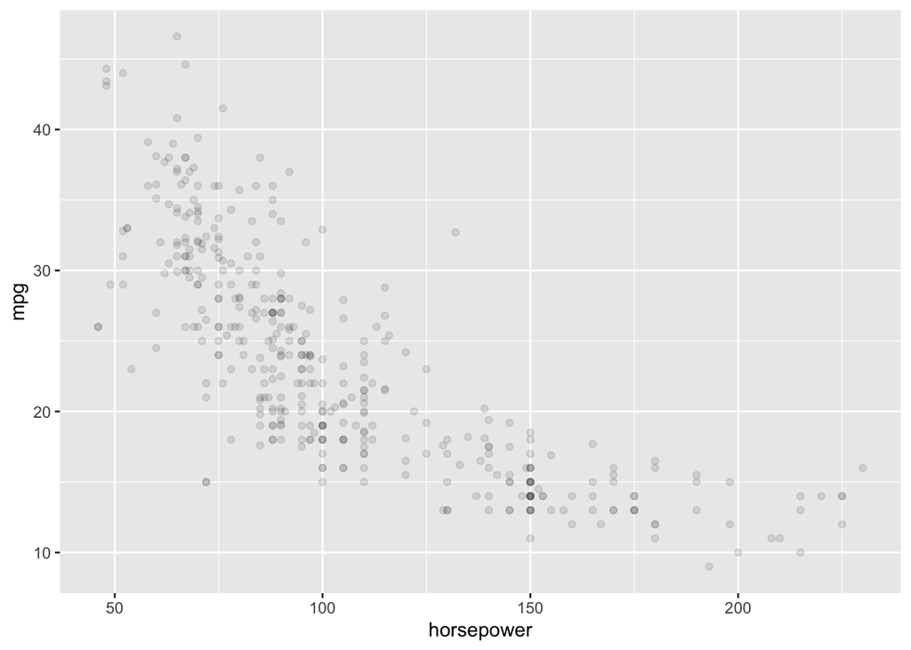

```r
# visualize each model

ggplot(Auto, aes(horsepower, mpg)) +
  geom_point(alpha = .1)
```

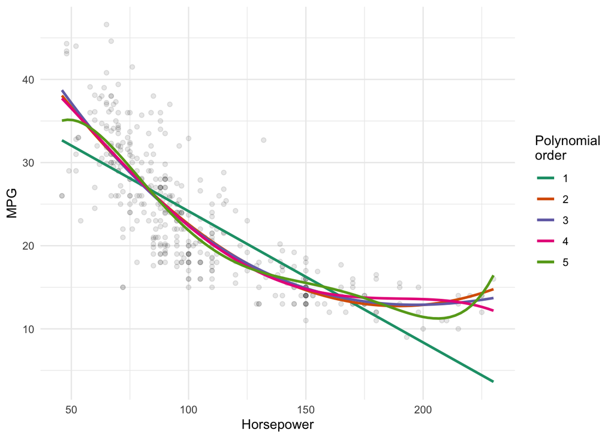

```r
ggplot(Auto, aes(horsepower, mpg)) +
  geom_point(alpha = .1) +
  geom_smooth(aes(color = "1"),
              method = "glm",
              formula = y ~ poly(x, i = 1, raw = TRUE),
              se = FALSE) +
  geom_smooth(aes(color = "2"),
              method = "glm",
              formula = y ~ poly(x, i = 2, raw = TRUE),
              se = FALSE) +
  geom_smooth(aes(color = "3"),
              method = "glm",
              formula = y ~ poly(x, i = 3, raw = TRUE),
              se = FALSE) +
  geom_smooth(aes(color = "4"),
              method = "glm",
              formula = y ~ poly(x, i = 4, raw = TRUE),
              se = FALSE) +
  geom_smooth(aes(color = "5"),
              method = "glm",
              formula = y ~ poly(x, i = 5, raw = TRUE),
              se = FALSE) +
  scale_color_brewer(type = "qual", palette = "Dark2") +
  labs(x = "Horsepower",
       y = "MPG",
       color = "Polynomial\norder") +
  theme_minimal()
```

```r
# function to train the model (training set) and evaluate the model (validation set), across each polynomial regression fit
poly_results <- function(train, test, i) {

  mod <- glm(mpg ~ poly(horsepower, i, raw = TRUE), data = train)

  res <- augment(mod,
                 newdata = test) %>%
    mse(truth = mpg,
        estimate = .fitted)
  res
}

# function to return MSE for a unique order polynomial term
library(magrittr)
```

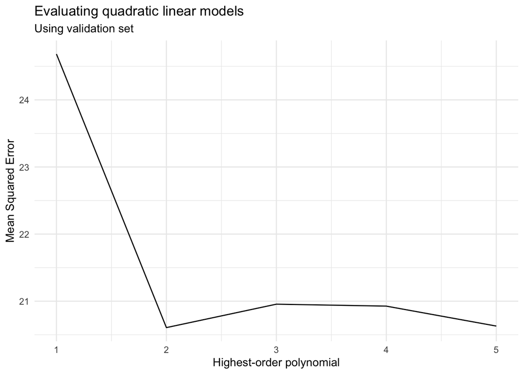

```r
poly_mse <- function(i, train, test){
  poly_results(train, test, i) %$%
    mean(.estimate)
}

cv_mse <- tibble(terms = seq(from = 1, to = 5),
                 mse_test = map_dbl(terms, poly_mse, auto_train, auto_test))

ggplot(cv_mse, aes(terms, mse_test)) +
  geom_line() +
  labs(title = "Evaluating quadratic linear models",
       subtitle = "Using validation set",
       x = "Highest-order polynomial",
       y = "Mean Squared Error") +
  theme_minimal()
```

## Classification

Predict passenger survival (yes or no) during the sinking of the Titanic.

```r
library(titanic)

titanic <- as_tibble(titanic_train) %>%
  mutate(Survived = factor(Survived))

titanic %>%
  head(n = 5)
```

| PassengerId | Survived | Pclass | Name | Sex | Age | SibSp | Parch | Ticket | Fare | Cabin | Embarked |
| --- | --- | --- | --- | --- | --- | --- | --- | --- | --- | --- | --- |
| 1 | 0 | 3 | Braund, Mr. Owen Harris | male | 22 | 1 | 0 | A/5 21171 | 7.2500 |  | S |
| 2 | 1 | 1 | Cumings, Mrs. John Bradley (Florence Briggs Thayer) | female | 38 | 1 | 0 | PC 17599 | 71.2833 | C85 | C |
| 3 | 1 | 3 | Heikkinen, Miss. Laina | female | 26 | 0 | 0 | STON/O2. 3101282 | 7.9250 |  | S |
| 4 | 1 | 1 | Futrelle, Mrs. Jacques Heath (Lily May Peel) | female | 35 | 1 | 0 | 113803 | 53.1000 | C123 | S |
| 5 | 0 | 3 | Allen, Mr. William Henry | male | 35 | 0 | 0 | 373450 | 8.0500 |  | S |

```r
survive_age_woman_x <- glm(Survived ~ Age * Sex, data = titanic,
                           family = binomial)
summary(survive_age_woman_x)
```

```
##
## Call:
## glm(formula = Survived ~ Age * Sex, family = binomial, data = titanic)
##
## Deviance Residuals:
##     Min       1Q   Median       3Q      Max
## -1.9401  -0.7136  -0.5883   0.7626   2.2455
##
## Coefficients:
##             Estimate Std. Error z value Pr(>|z|)
## (Intercept)  0.59380    0.31032   1.913  0.05569 .
## Age          0.01970    0.01057   1.863  0.06240 .
## Sexmale     -1.31775    0.40842  -3.226  0.00125 **
## Age:Sexmale -0.04112    0.01355  -3.034  0.00241 **
## ---
## Signif. codes:  0 '***' 0.001 '**' 0.01 '*' 0.05 '.' 0.1 ' ' 1
##
## (Dispersion parameter for binomial family taken to be 1)
##
##     Null deviance: 964.52  on 713  degrees of freedom
## Residual deviance: 740.40  on 710  degrees of freedom
##   (177 observations deleted due to missingness)
## AIC: 748.4
##
## Number of Fisher Scoring iterations: 4
```

```r
# helper function to convert log-odds to probabilities
logit2prob <- function(x){
  exp(x) / (1 + exp(x))
}
```

```r
# split the data into training and validation sets
titanic_split <- initial_split(data = titanic,
                               prop = 0.5)

# fit model to training data
train_model <- glm(Survived ~ Age * Sex,
                   data = training(titanic_split),
                   family = binomial); broom::tidy(train_model)
```

| term | estimate | std.error | statistic | p.value |
| --- | --- | --- | --- | --- |
| (Intercept) | 0.71969732 | 0.45144462 | 1.594210 | 0.11088911 |
| Age | 0.01912998 | 0.01551725 | 1.232821 | 0.21764263 |
| Sexmale | -1.38816405 | 0.58637123 | -2.367381 | 0.01791449 |
| Age:Sexmale | -0.03885845 | 0.01953846 | -1.988819 | 0.04672121 |

```r
# calculate predictions using validation set
x_test_accuracy <- augment(train_model,
                           newdata = testing(titanic_split)) %>%
  as_tibble() %>%
  mutate(.prob = logit2prob(.fitted),
         .pred = factor(round(.prob)))

# calculate test accuracy rate from yardstick
accuracy(x_test_accuracy,
         truth = Survived,
         estimate = .pred)
```

| .metric | .estimator | .estimate |
| --- | --- | --- |
| accuracy | binary | 0.784153 |

Let’s jump into CV a bit more, starting with LOOCV.

# LOOCV

## LOOCV in regression

```r
library(tidyverse)
library(ISLR)
library(broom)
library(rsample)
library(rcfss)
library(yardstick)

loocv_data <- loo_cv(Auto)

loocv_data %>%
  names()
```

```
## [1] "splits" "id"
```

```r
first_resample <- loocv_data$splits[[1]]
first_resample
```

```
## <Analysis/Assess/Total>
## <391/1/392>
```

```r
# but first, note training() and analysis() from resample contain same information; just different forms
first_resample %>%
  analysis() %>% # data frame version
  head(n = 5)
```

| mpg | cylinders | displacement | horsepower | weight | acceleration | year | origin | name |
| --- | --- | --- | --- | --- | --- | --- | --- | --- |
| 18 | 8 | 307 | 130 | 3504 | 12.0 | 70 | 1 | chevrolet chevelle malibu |
| 15 | 8 | 350 | 165 | 3693 | 11.5 | 70 | 1 | buick skylark 320 |
| 18 | 8 | 318 | 150 | 3436 | 11.0 | 70 | 1 | plymouth satellite |
| 16 | 8 | 304 | 150 | 3433 | 12.0 | 70 | 1 | amc rebel sst |
| 17 | 8 | 302 | 140 | 3449 | 10.5 | 70 | 1 | ford torino |

```r
first_resample %>%
  training() %>%
  head(n = 5)
```

| mpg | cylinders | displacement | horsepower | weight | acceleration | year | origin | name |
| --- | --- | --- | --- | --- | --- | --- | --- | --- |
| 18 | 8 | 307 | 130 | 3504 | 12.0 | 70 | 1 | chevrolet chevelle malibu |
| 15 | 8 | 350 | 165 | 3693 | 11.5 | 70 | 1 | buick skylark 320 |
| 18 | 8 | 318 | 150 | 3436 | 11.0 | 70 | 1 | plymouth satellite |
| 16 | 8 | 304 | 150 | 3433 | 12.0 | 70 | 1 | amc rebel sst |
| 17 | 8 | 302 | 140 | 3449 | 10.5 | 70 | 1 | ford torino |

```r
# same with assessment() and testing()
first_resample %>%
  assessment() %>%
  head(n = 5)
```

| mpg | cylinders | displacement | horsepower | weight | acceleration | year | origin | name |
| --- | --- | --- | --- | --- | --- | --- | --- | --- |
| 18.5 | 8 | 360 | 150 | 3940 | 13 | 79 | 1 | chrysler lebaron town @ country (sw) |

```r
first_resample %>%
  testing() %>%
  head(n = 5)
```

| mpg | cylinders | displacement | horsepower | weight | acceleration | year | origin | name |
| --- | --- | --- | --- | --- | --- | --- | --- | --- |
| 18.5 | 8 | 360 | 150 | 3940 | 13 | 79 | 1 | chrysler lebaron town @ country (sw) |

```r
holdout_results <- function(splits) {
  mod <- glm(mpg ~ horsepower, data = analysis(splits))

  res <- augment(mod, newdata = assessment(splits)) %>%
    mse(truth = mpg, estimate = .fitted)

  res
}
```

This function works also for a single resample:

```r
holdout_results(loocv_data$splits[[1]])
```

| .metric | .estimator | .estimate |
| --- | --- | --- |
| mse | standard | 5.083533 |

```r
loocv_data_poly1 <- loocv_data %>%
  mutate(results = map(splits, holdout_results)) %>%
  unnest(results) %>%
  spread(.metric, .estimate)

loocv_data_poly1 %>%
  head(n = 5)
```

| splits | id | .estimator | mse |
| --- | --- | --- | --- |
|  | Resample1 | standard | 5.0835330 |
|  | Resample2 | standard | 49.9405256 |
|  | Resample3 | standard | 44.1228965 |
|  | Resample4 | standard | 25.3016852 |
|  | Resample5 | standard | 0.5377148 |

```r
loocv_data_poly1 %>%
  summarize(mse = mean(mse))
```

| mse |
| --- |
| 24.23151 |

```r
# modified function to estimate model with varying polynomial order
holdout_results <- function(splits, i) {
  mod <- glm(mpg ~ poly(horsepower, i, raw = TRUE),
             data = analysis(splits))

  res <- augment(mod, newdata = assessment(splits)) %>%
    mse(truth = mpg, estimate = .fitted)
  res
}

# function to return MSE for a specific polynomial term
poly_mse <- function(i, loocv_data){
  loocv_mod <- loocv_data %>%
    mutate(results = map(splits, holdout_results, i)) %>%
    unnest(results) %>%
    spread(.metric, .estimate)

  mean(loocv_mod$mse)
}

library(tictoc)

{ # wrap and time
tic()
cv_mse <- tibble(terms = seq(from = 1, to = 5),
                 mse_loocv = map_dbl(terms, poly_mse, loocv_data))
toc()
}
```

```
## 35.337 sec elapsed
```

```r
cv_mse
```

| terms | mse_loocv |
| --- | --- |
| 1 | 24.23151 |
| 2 | 19.24821 |
| 3 | 19.33498 |
| 4 | 19.42443 |
| 5 | 19.03321 |

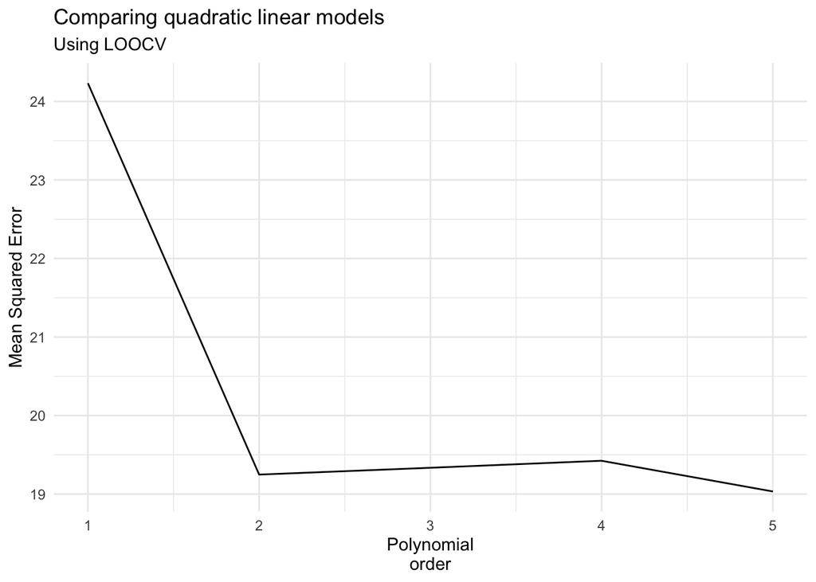

```r
ggplot(cv_mse, aes(terms, mse_loocv)) +
  geom_line() +
  labs(title = "Comparing quadratic linear models",
       subtitle = "Using LOOCV",
       x = "Polynomial\norder",
       y = "Mean Squared Error") +
  theme_minimal()
```

## LOOCV in classification

Let’s verify the error rate of our interactive terms model for the Titanic data set:

```r
#library(titanic) # re-load if a new session

titanic <- as_tibble(titanic_train) %>%
  mutate(Survived = factor(Survived))

# Now, write a function to generate assessment statistics for titanic model
holdout_results <- function(splits) {
  mod <- glm(Survived ~ Age * Sex, data = analysis(splits),
             family = binomial)

  res <- augment(mod, newdata = assessment(splits)) %>%
    as_tibble() %>%
    mutate(.prob = logit2prob(.fitted),
           .pred = round(.prob))
  res
}

titanic_loocv <- loo_cv(titanic) %>%
  mutate(results = map(splits, holdout_results)) %>%
  unnest(results) %>%
  mutate(.pred = factor(.pred)) %>%
  group_by(id) %>%
  accuracy(truth = Survived, estimate = .pred)

1 - mean(titanic_loocv$.estimate, na.rm = TRUE)
```

```
## [1] 0.219888
```

# k-fold CV

Back to the `Auto` data set and comparing across polynomial orders.

```r
# our helper function to estimate model with varying highest order polynomial
holdout_results <- function(splits, i) {
  mod <- glm(mpg ~ poly(horsepower, i, raw = TRUE), data = analysis(splits))

  holdout <- assessment(splits)

  res <- augment(mod, newdata = holdout) %>%
    mse(truth = mpg, estimate = .fitted)

  res
}

# function to return MSE for a specific fit
poly_mse <- function(i, vfold_data){
  vfold_mod <- vfold_data %>%
    mutate(results = map(splits, holdout_results, i)) %>%
    unnest(results) %>%
    spread(.metric, .estimate)

  mean(vfold_mod$mse)
}

# split Auto into 10 folds
auto_cv10 <- vfold_cv(data = Auto,
                      v = 10)

# as before...
auto_cv10 %>%
  names()
```

```
## [1] "splits" "id"
```

```r
cv_mse <- tibble(terms = seq(from = 1,
                             to = 5),
                 mse_vfold = map_dbl(terms, poly_mse, auto_cv10))
cv_mse
```

| terms | mse_vfold |
| --- | --- |
| 1 | 24.34221 |
| 2 | 19.21660 |
| 3 | 19.23460 |
| 4 | 19.31027 |
| 5 | 19.00340 |

Looks similar on first glance, but how do these results compare to the LOOCV procedure?

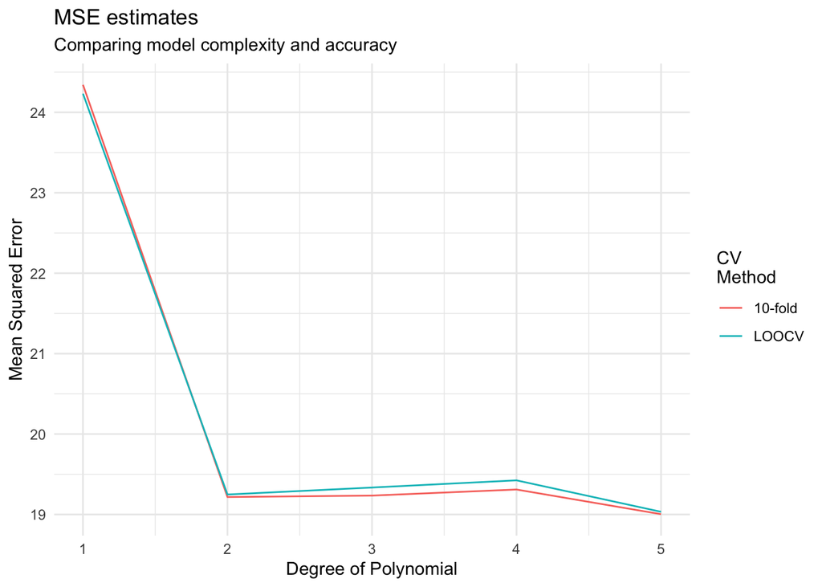

```r
auto_loocv <- loo_cv(Auto)

tibble(terms = seq(from = 1, to = 5), # takes a few seconds, given the mapping
       `10-fold` = map_dbl(terms, poly_mse, auto_cv10),
       LOOCV = map_dbl(terms, poly_mse, auto_loocv)
) %>%
  gather(method, MSE, -terms) %>%
  ggplot(aes(terms, MSE, color = method)) +
  geom_line() +
  labs(title = "MSE estimates",
       subtitle = "Comparing model complexity and accuracy",
       x = "Degree of Polynomial",
       y = "Mean Squared Error",
       color = "CV\nMethod") +
  theme_minimal()
```

# On your own

For this section, you will work in small groups of 4-5. *I will create these groups at random*.

**IMPORTANT**: *Don’t forget that this code you’re working on here is due at the appropriate Canvas module (in the form of an attachment to a “Discussion” post) prior to 5:00 pm CDT today. You need only submit a **single** file/script to be considered for credit (i.e., this .Rmd with your code inserted below each question). Recall, I don’t care whether you got things right. I only care that attempts to each question have been made.*

Return to the Titanic data, and apply 10-fold cross validation to a classification task. As noted before, though we haven’t covered classification yet, you should have seen enough in today’s session to complete (or at least attempt) the following. I will get you started with the packages and data needed to respond to each prompt below.

```r
library(tidyverse)
library(tidymodels)
library(titanic)

titanic <- as_tibble(titanic_train) %>%
  mutate(Survived = factor(Survived))
```

1. Use 10-fold cross validation to build and evaluate a logistic regression predicting `Survived` as a function of interacting `Age` and `Sex`. To answer this, you will need to:
1. Build the classifer on the training set(s) across folds
2. Evaluate each classifer using the test set(s) across folds

```r
holdout_results <- function(splits) {
  mod <- glm(Survived ~ Age * Sex, data = analysis(splits),
             family = binomial)
  res <- augment(mod, newdata = assessment(splits)) %>%
    as_tibble() %>%
    mutate(.prob = logit2prob(.fitted),
           .pred = round(.prob))
  res
}

titanic_cv10 <- vfold_cv(data = titanic, v = 10) %>%
  mutate(results = map(splits, holdout_results)) %>%
  unnest(results) %>%
  mutate(.pred = factor(.pred)) %>%
  group_by(id) %>%
  accuracy(truth = Survived,
           estimate = .pred)
titanic_cv10
```

| id | .metric | .estimator | .estimate |
| --- | --- | --- | --- |
| Fold01 | accuracy | binary | 0.8000000 |
| Fold02 | accuracy | binary | 0.7611940 |
| Fold03 | accuracy | binary | 0.7903226 |
| Fold04 | accuracy | binary | 0.7236842 |
| Fold05 | accuracy | binary | 0.8591549 |
| Fold06 | accuracy | binary | 0.8243243 |
| Fold07 | accuracy | binary | 0.7625000 |
| Fold08 | accuracy | binary | 0.6901408 |
| Fold09 | accuracy | binary | 0.8243243 |
| Fold10 | accuracy | binary | 0.7681159 |

2. Calculate the cross-validation *error rate* (not the accuracy rate) from your solution and report it.

```r
1 - mean(titanic_cv10$.estimate, na.rm = TRUE)
```

```
## [1] 0.2196239
```

3. Is this similar to the error from using LOOCV earlier in the session? Why or why not, do you think? (offer just a couple thoughts on the patterns – differences and similarities in error, computational speed, etc. – from each approach to resampling in this classification setting).

**ANSWER**: Not a huge difference from the LOOCV approach, but it takes much less time to compute.